# RNASeq normalization

Nisha_paudel

2023-02-05

## **Introduction of Normalization**

Normalization or normalisation refers to **a process that makes something more normal or regular.** Normalization is an important step in the RNA-seq analysis pipeline, as it is used to make the data comparable across different samples.The first step in the DE analysis workflow is count normalization.Normalisation is required to ensure that the expression distributions of each sample are similar across the entire experiment.

## **Multiple bias in RNAseq experiment :**

1. Sequencing depth [12]
2. Gene length [12,15]
3. Sequencing composition [14,15]
4. Batch effects[12]
5. Mapping and annotation bias [13]

### **1. Library size**

The most well know bias. You create two libraries for two conditions with the same RNA composition. The second library works way better than the first one, you got 12 000 000 reads for condition A and 36 000 000 reads for condition B. You will have three times (36 000 000/12 000 000 = 3) more of each RNA in your condition B than your condition A. ([pub3](https://www.ncbi.nlm.nih.gov/pmc/articles/PMC4728800/))

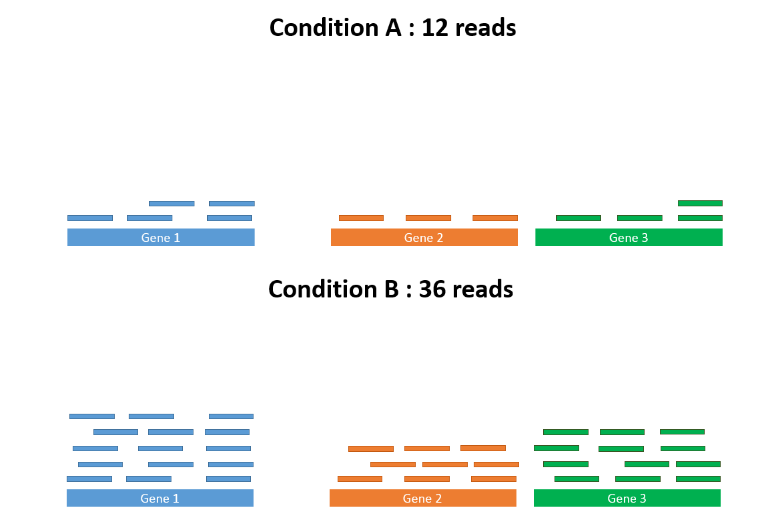

### **2. Gene Length**

The raw count of two genes cannot be face off if gene A is twice longer than gene B. Due to its length, the longest gene will have much chance to be sequenced than the short one. And in the end, for the same expression level, the longest gene will get more read than the shortest one ([pub1](https://www.ncbi.nlm.nih.gov/pubmed/28529717))

### **3. RNA composition Biasses**

A small number of genes can consume a signifi cant fraction of the sequencing resources, causing an undersampling of the remaining genes If not explicitly accounted for, this undersampling induces a bias to the detection of DE (Robinson and Oshlack 2010 ) . To compensate for such composition effects, scaling factors in addition to the adjustment made for depth can be calculated

### **4. Batch effect**

Batch effect correction targets variance from experimental designs and handling (dfferent sequencing platforms, timing, reagents, laboratories, etc.)

## **Importance of normalization**

While normalization is essential for differential expression analyses, it is also necessary for exploratory data analysis, visualization of data, and whenever you are exploring or comparing counts between or within samples.

## **Common Normalization methods in RNA seq**

[output not shown]

## 1. RPM/CPM

It is a basic gene expression unit that normalizes only for sequencing depth (depth-normalized counts). The RPM is biased in some applications where the gene length influences gene expression, such as RNA-seq.RPM is calculated by dividing the mapped reads count by a per million scaling factor of total mapped reads.

## 2. RPKM/FPKM(Reads/Transcripts per kilo base of transcript per million mapped reads)

RPKM (reads per kilobase of transcript per million reads mapped) is a gene expression unit that measures the expression levels (mRNA abundance) of genes or transcripts. RPKM is a gene length normalized expression unit that is used for identifying the differentially expressed genes by comparing the RPKM values between different experimental conditions. Generally, the higher the RPKM of a gene, the higher the expression of that gene.

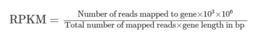

Here, 10<sup>3</sup> normalizes for gene length and 10<sup>6</sup> for sequencing depth factor.

FPKM (Fragments per kilo base of transcript per million mapped fragments) is a gene expression unit which is analogous to RPKM. FPKM is used especially for normalizing counts for paired-end RNA-seq data in which two (left and right) reads are sequenced from the same DNA fragment. Generally, the higher the FPKM of a gene, the higher the expression of that gene.

## 3. TPM (Transcripts per million)

TPM is proposed as an alternative to RPKM because of inaccuracy in RPKM measurement. TPM considers the gene length for normalization. TPM is suitable for sequencing protocols where reads sequencing depends on gene length. TMM is implemented in edgeR and performs better for between-samples comparisons.

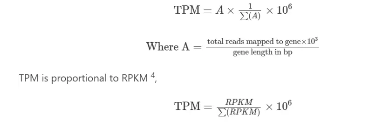

## 4. TMM (Trimmed Mean of M-values)

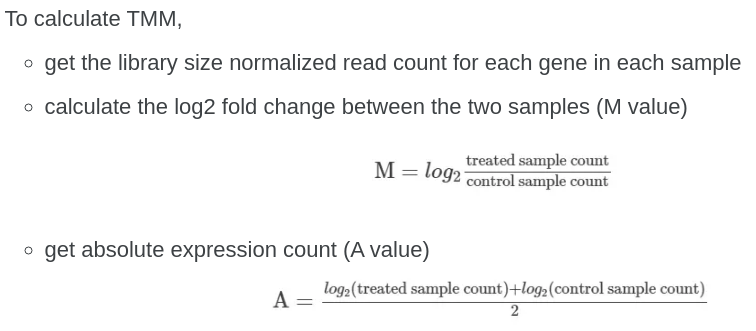

- Now, double trim the upper and lower percentages of the data (trim M values by 30% and A values by 5%)

Get weighted mean of M after trimming and calculate normalization factor ( see Robinson et al., 2010 for details)

This normalization method is based on the hypothesis that most genes are not differentially expressed (DE). For each sample, the TMM factor is computed while one sample is considered as a reference sample and the others as test samples. For each test sample, after exclusion of the most expressed genes and the genes with the largest log ratios, TMM is computed as the weighted mean of log ratios between this test and the reference. Because of the low DE hypothesis, the TMM should be close to 1. If it is not, its value provides an estimate of the correction factor that must be applied to the library sizes [21]. This normalization method is implemented in the edgeR Bioconductor package as the default normalization method

## 5. Upper Quartile (UQ)

Under this normalization method, after removing genes having zero read counts for all samples, the remaining gene counts are divided by the upper quartile of counts different from zero in the computation of the normalization factors associated with their sample and multiplied by the mean upper quartile across all samples of the dataset [12]. This normalization method is implemented in the EDASeq and edgeR Bioconductor packages [32,33]

## 7. GeTMM (Gene length corrected trimmed mean of M-values)

GeTMM, which allows for both inter- and intrasample analyses with the same normalized data set. GeTMM outperforms established methods with regard to intrasample comparison while performing equivalent with regard to intersample normalization using the same normalized data. These combined properties enhance the general usefulness of RNA-seq but also the comparability to the many array-based gene expression data in the public domain.

https://bmcbioinformatics.biomedcentral.com/articles/10.1186/s12859-018-2246-7

## 8. DEseq2: median ratio

The *DESeq*2 normalization method is similar to TMM. *DESeq* normalization method also assumes that most of the genes are not differentially expressed.

## 9. Combat Seq

It is a batch correction method, ComBat-seq, using a negative binomial regression model that retains the integer nature of count data in RNA-seq studies, making the batch adjusted data compatible with common differential expression software packages that require integer counts. [ComBat-Seq](https://github.com/zhangyuqing/ComBat-seq)

## 10. Others

It is possible below mentioned methods that some of the estimated latent factors are not technical artifacts but rather represent true biology presented in the data. Thus, it is important to adjust for any known biological factors of interest and known technical artifacts prior to estimation of latent factors

### 1. Noiseq

NOISeq is R package for analyzing count data, it consists of three modules: (1) Quality control of count data; (2) Normalization and low-count filtering; and (3) Differential expression analysis. It consists of various functions for visualizing and correcting the biases. https://www.bioconductor.org/packages/release/bioc/vignettes/NOISeq/inst/doc/NOISeq.pdf

### 2. RUV (Remove unwanted variation)

Implements the 'RUV' (Remove Unwanted Variation) algorithms. These algorithms attempt to adjust for systematic errors of unknown origin in high-dimensional data.

RUV method was proposed to adjust for unknown technical variations by performing factor analysis on negative control genes (i.e., genes known not to be related to the primary factor of interest) [17,37]. Therefore, variations in the expression levels of these genes can be assumed to be unwanted variations. Housekeeping genes [38] or spike-in controls [39] are the examples of negative controls. However, RUV method does not need the negative control genes or samples [17].

Under this approach, the factors of unknown technical variations are estimated and removed by performing the factor analysis on suitable sets of negative control genes or samples by keeping the primary factor of interest. Therefore, RUV [17] method is divided into three sub-methods: RUVg, RUVs, and RUVr. The RUVg and RUVs are used when negative control genes and negative control samples (i.e., samples whose read counts are not influenced by the primary factor of interest) exist. However, RUVr (i.e., residual RUV) does not require the existence of negative control genes or samples. SVD is then computed on the residual matrix to estimate the factors of unknown technical variations. The number of factors of unwanted variation, k, should be guided by considerations that include samples sizes, extent of technical effects captured by the first k factors, and extent of differential expression [17,25].

https://www.nature.com/articles/s41587-022-01440-w

### 3. SVA (Surrogate Variable Analysis)

The general form of the sva algorithm relies on the idea that there is a subset of genes, probes or transcripts that are affected by unknown batch effects or other artifacts but are not affected by the biological relationship of interest. Other commonly used methods to address this problem in identifying the unknown technical variations are the surrogate variable analysis (SVA) [18]. In this approach, the unknown technical variations or “surrogate variables” (SV’s) are estimated by applying SVD on the computed residual matrix and selecting significant eigenvectors [18,25,42]. The first step in SVA is to determine the number of SVs using one of the two methods, “BE” or “Leek” as noted in [18,26,43]. The “BE” method is based on a permutation procedure originally proposed by Buja and Eyuboglu [43], while the “Leek” method provides an interface to the asymptotic approach proposed by Leek [42], where under the specific assumptions, the right singular vectors are asymptotically consistent for latent artifacts as the number of features grows large. Once the number of SVs is calculated, then using the two-step algorithm following Leek and Storey [18] to estimate unknown technical artifacts.

https://academic.oup.com/nar/article/42/21/e161/2903156

### 4. PCA

One can determine the number of PCs to include in the model by multiple methods, including: PCs that explain a given percent of the variation; PCs that are associated with the biological factors of interest (i.e., confounders); top PCs regardless of association with the primary factors of interest; application of the Tracy-Widom test for determining eigenvalues significantly different from zero (noting that the assumption of independence is not valid) [45–47]; or determine the PCs to include based on a permutation testing approach similar to that implemented in the SVA method.

## Which normalization technique should we use?

It depends on research question, nature of data and distribution of data.

## Glossary

**spike-ins** : In RNA-Seq analyses, adding pre-determined quantity of synthetic RNA sequences (spike-ins) to samples is a popular way to verify the experimental pipeline, determine quantification accuracy and for normalisation of differential expression. The most commonly used spike-ins are the ERCC spike-ins

## **References**

GeTMM : Smid M, van den Braak RR, van de Werken HJ, van Riet J, van Galen A, de Weerd V, van der Vlugt-Daane M, Bril SI, Lalmahomed ZS, Kloosterman WP, Wilting SM. Gene length corrected trimmed mean of M-values (GeTMM) processing of RNA-seq data performs similarly in intersample analyses while improving intrasample comparisons. BMC bioinformatics. 2018 Dec;19(1):1-3